# Risk Factor Analysis

## Outcome Variable

**Outcome Variable:** haz

## Predictor Variables

**Intervention Variable:** predexfd6

**Adjustment Set:**

- arm
- sex
- brthmon
- W_mage
- meducyrs
- feducyrs
- hhwealth_quart
- hfoodsec
- W_mhtcm
- W_mwtkg
- W_mbmi
- vagbrth
- W_gagebrth
- W_birthwt
- W_birthlen
- W_nrooms
- W_nchldlt5
- month
- W_parity
- impfloor
- impsan
- safeh20
- delta_W_mage
- delta_meducyrs
- delta_feducyrs
- delta_hhwealth_quart
- delta_hfoodsec
- delta_W_mhtcm
- delta_W_mwtkg
- delta_W_mbmi
- delta_vagbrth
- delta_W_gagebrth
- delta_W_birthwt
- delta_W_birthlen
- delta_W_nrooms
- delta_W_nchldlt5
- delta_month
- delta_W_parity
- delta_impfloor
- delta_impsan
- delta_safeh20

## Stratifying Variables

The analysis was stratified on these variable(s):

- agecat
- studyid
- country

## Data Summary

| agecat | studyid | country | predexfd6 | n_cell | n |
| --- | --- | --- | --- | --- | --- |
| Birth | ki0047075b-MAL-ED | BANGLADESH | 1 | 72 | 205 |
| Birth | ki0047075b-MAL-ED | BANGLADESH | 0 | 133 | 205 |
| Birth | ki0047075b-MAL-ED | BRAZIL | 1 | 6 | 60 |
| Birth | ki0047075b-MAL-ED | BRAZIL | 0 | 54 | 60 |
| Birth | ki0047075b-MAL-ED | INDIA | 1 | 4 | 39 |
| Birth | ki0047075b-MAL-ED | INDIA | 0 | 35 | 39 |
| Birth | ki0047075b-MAL-ED | NEPAL | 1 | 3 | 24 |
| Birth | ki0047075b-MAL-ED | NEPAL | 0 | 21 | 24 |
| Birth | ki0047075b-MAL-ED | PERU | 1 | 73 | 213 |
| Birth | ki0047075b-MAL-ED | PERU | 0 | 140 | 213 |
| Birth | ki0047075b-MAL-ED | SOUTH AFRICA | 1 | 1 | 91 |
| Birth | ki0047075b-MAL-ED | SOUTH AFRICA | 0 | 90 | 91 |
| Birth | ki0047075b-MAL-ED | TANZANIA, UNITED REPUBLIC OF | 1 | 0 | 113 |
| Birth | ki0047075b-MAL-ED | TANZANIA, UNITED REPUBLIC OF | 0 | 113 | 113 |
| Birth | ki1000108-CMC-V-BCS-2002 | INDIA | 1 | 7 | 7 |
| Birth | ki1000108-CMC-V-BCS-2002 | INDIA | 0 | 0 | 7 |
| Birth | ki1000108-IRC | INDIA | 1 | 0 | 14 |
| Birth | ki1000108-IRC | INDIA | 0 | 14 | 14 |
| Birth | ki1000109-EE | PAKISTAN | 1 | 38 | 42 |
| Birth | ki1000109-EE | PAKISTAN | 0 | 4 | 42 |
| Birth | ki1000304b-SAS-CompFeed | INDIA | 1 | 346 | 364 |
| Birth | ki1000304b-SAS-CompFeed | INDIA | 0 | 18 | 364 |
| Birth | ki1017093b-PROVIDE | BANGLADESH | 1 | 159 | 539 |
| Birth | ki1017093b-PROVIDE | BANGLADESH | 0 | 380 | 539 |
| Birth | ki1101329-Keneba | GAMBIA | 1 | 485 | 1403 |
| Birth | ki1101329-Keneba | GAMBIA | 0 | 918 | 1403 |
| Birth | ki1113344-GMS-Nepal | NEPAL | 1 | 419 | 563 |
| Birth | ki1113344-GMS-Nepal | NEPAL | 0 | 144 | 563 |
| Birth | kiGH5241-JiVitA-3 | BANGLADESH | 1 | 10466 | 13423 |
| Birth | kiGH5241-JiVitA-3 | BANGLADESH | 0 | 2957 | 13423 |

[output cut: 70 more lines]

The following strata were considered:

- agecat: 24 months, studyid: ki0047075b-MAL-ED, country: BANGLADESH
- agecat: 24 months, studyid: ki0047075b-MAL-ED, country: BRAZIL
- agecat: 24 months, studyid: ki0047075b-MAL-ED, country: INDIA
- agecat: 24 months, studyid: ki0047075b-MAL-ED, country: NEPAL
- agecat: 24 months, studyid: ki0047075b-MAL-ED, country: PERU
- agecat: 24 months, studyid: ki0047075b-MAL-ED, country: SOUTH AFRICA
- agecat: 24 months, studyid: ki0047075b-MAL-ED, country: TANZANIA, UNITED REPUBLIC OF
- agecat: 24 months, studyid: ki1000108-CMC-V-BCS-2002, country: INDIA
- agecat: 24 months, studyid: ki1000108-IRC, country: INDIA
- agecat: 24 months, studyid: ki1000109-EE, country: PAKISTAN
- agecat: 24 months, studyid: ki1017093b-PROVIDE, country: BANGLADESH
- agecat: 24 months, studyid: ki1101329-Keneba, country: GAMBIA
- agecat: 24 months, studyid: ki1113344-GMS-Nepal, country: NEPAL
- agecat: 24 months, studyid: ki1148112-LCNI-5, country: MALAWI
- agecat: 24 months, studyid: kiGH5241-JiVitA-3, country: BANGLADESH
- agecat: 24 months, studyid: kiGH5241-JiVitA-4, country: BANGLADESH
- agecat: 6 months, studyid: ki0047075b-MAL-ED, country: BANGLADESH
- agecat: 6 months, studyid: ki0047075b-MAL-ED, country: BRAZIL
- agecat: 6 months, studyid: ki0047075b-MAL-ED, country: INDIA
- agecat: 6 months, studyid: ki0047075b-MAL-ED, country: NEPAL
- agecat: 6 months, studyid: ki0047075b-MAL-ED, country: PERU
- agecat: 6 months, studyid: ki0047075b-MAL-ED, country: SOUTH AFRICA
- agecat: 6 months, studyid: ki0047075b-MAL-ED, country: TANZANIA, UNITED REPUBLIC OF
- agecat: 6 months, studyid: ki1000108-CMC-V-BCS-2002, country: INDIA
- agecat: 6 months, studyid: ki1000108-IRC, country: INDIA
- agecat: 6 months, studyid: ki1000109-EE, country: PAKISTAN
- agecat: 6 months, studyid: ki1000304b-SAS-CompFeed, country: INDIA
- agecat: 6 months, studyid: ki1000304b-SAS-FoodSuppl, country: INDIA
- agecat: 6 months, studyid: ki1017093b-PROVIDE, country: BANGLADESH
- agecat: 6 months, studyid: ki1101329-Keneba, country: GAMBIA
- agecat: 6 months, studyid: ki1113344-GMS-Nepal, country: NEPAL
- agecat: 6 months, studyid: ki1148112-LCNI-5, country: MALAWI
- agecat: 6 months, studyid: kiGH5241-JiVitA-3, country: BANGLADESH
- agecat: 6 months, studyid: kiGH5241-JiVitA-4, country: BANGLADESH
- agecat: Birth, studyid: ki0047075b-MAL-ED, country: BANGLADESH
- agecat: Birth, studyid: ki0047075b-MAL-ED, country: BRAZIL
- agecat: Birth, studyid: ki0047075b-MAL-ED, country: INDIA
- agecat: Birth, studyid: ki0047075b-MAL-ED, country: NEPAL
- agecat: Birth, studyid: ki0047075b-MAL-ED, country: PERU
- agecat: Birth, studyid: ki0047075b-MAL-ED, country: SOUTH AFRICA
- agecat: Birth, studyid: ki0047075b-MAL-ED, country: TANZANIA, UNITED REPUBLIC OF
- agecat: Birth, studyid: ki1000108-CMC-V-BCS-2002, country: INDIA
- agecat: Birth, studyid: ki1000108-IRC, country: INDIA
- agecat: Birth, studyid: ki1000109-EE, country: PAKISTAN
- agecat: Birth, studyid: ki1000304b-SAS-CompFeed, country: INDIA
- agecat: Birth, studyid: ki1017093b-PROVIDE, country: BANGLADESH
- agecat: Birth, studyid: ki1101329-Keneba, country: GAMBIA
- agecat: Birth, studyid: ki1113344-GMS-Nepal, country: NEPAL
- agecat: Birth, studyid: kiGH5241-JiVitA-3, country: BANGLADESH
- agecat: Birth, studyid: kiGH5241-JiVitA-4, country: BANGLADESH

### Dropped Strata

Some strata were dropped due to rare outcomes:

- agecat: Birth, studyid: ki0047075b-MAL-ED, country: INDIA
- agecat: Birth, studyid: ki0047075b-MAL-ED, country: NEPAL
- agecat: Birth, studyid: ki0047075b-MAL-ED, country: SOUTH AFRICA
- agecat: Birth, studyid: ki0047075b-MAL-ED, country: TANZANIA, UNITED REPUBLIC OF
- agecat: Birth, studyid: ki1000108-CMC-V-BCS-2002, country: INDIA
- agecat: Birth, studyid: ki1000108-IRC, country: INDIA
- agecat: Birth, studyid: ki1000109-EE, country: PAKISTAN
- agecat: 6 months, studyid: ki0047075b-MAL-ED, country: SOUTH AFRICA
- agecat: 6 months, studyid: ki0047075b-MAL-ED, country: TANZANIA, UNITED REPUBLIC OF
- agecat: 6 months, studyid: ki1000108-CMC-V-BCS-2002, country: INDIA
- agecat: 6 months, studyid: ki1000108-IRC, country: INDIA
- agecat: 6 months, studyid: ki1000304b-SAS-FoodSuppl, country: INDIA
- agecat: 24 months, studyid: ki0047075b-MAL-ED, country: SOUTH AFRICA
- agecat: 24 months, studyid: ki0047075b-MAL-ED, country: TANZANIA, UNITED REPUBLIC OF
- agecat: 24 months, studyid: ki1000108-CMC-V-BCS-2002, country: INDIA
- agecat: 24 months, studyid: ki1000108-IRC, country: INDIA
- agecat: 24 months, studyid: ki1000109-EE, country: PAKISTAN

## Methods Detail

We’re interested in the causal parameters $E[Y_a]$ for all values of $a \in \mathcal{A}$. These parameters represent the mean outcome if, possibly contrary to fact, we intervened to set all units to have $A=a$. Under the randomization and positivity assumptions, these are identified by the statistical parameters $\psi_a=E_W[E_{Y|A,W}(Y|A=a,W)]$. In addition, we’re interested in the mean of $Y$, $E[Y]$ under no intervention (the observed mean). We will estimate these parameters by using SuperLearner to fit the relevant likelihood factors – $E_{Y|A,W}(Y|A=a,W)$ and $p(A=a|W)$, and then updating our likelihood fit using a joint TMLE.

For unadjusted analyses ($W=\{\}$), initial likelihoods were estimated using Lrnr_glm to estimate the simple $E(Y|A)$ and Lrnr_mean to estimate $p(A)$. For adjusted analyses, a small library containing Lrnr_glmnet, Lrnr_xgboost, and Lrnr_mean was used.

Having estimated these parameters, we will then use the delta method to estimate relative risks and attributable risks relative to a prespecified baseline level of $A$.

# Results Detail

## Results Plots

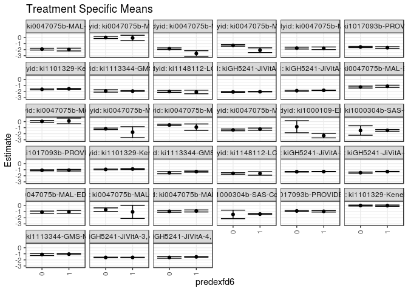

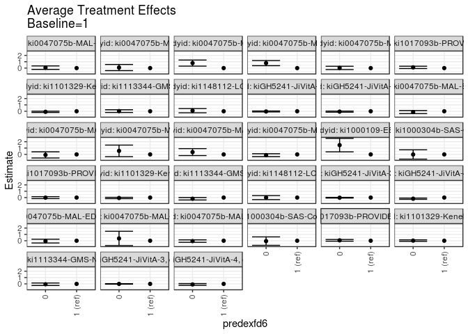

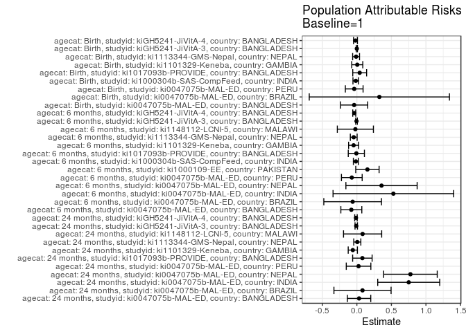

## Results Table

### Parameter: TSM

| agecat | studyid | country | intervention_level | baseline_level | estimate | ci_lower | ci_upper |
| --- | --- | --- | --- | --- | --- | --- | --- |
| Birth | ki0047075b-MAL-ED | BANGLADESH | 1 | NA | -1.0133351 | -1.2463298 | -0.7803404 |
| Birth | ki0047075b-MAL-ED | BANGLADESH | 0 | NA | -1.0679123 | -1.2482783 | -0.8875463 |
| Birth | ki0047075b-MAL-ED | BRAZIL | 1 | NA | -1.0216667 | -2.1085384 | 0.0652051 |
| Birth | ki0047075b-MAL-ED | BRAZIL | 0 | NA | -0.6601852 | -0.9595686 | -0.3608018 |
| Birth | ki0047075b-MAL-ED | PERU | 1 | NA | -0.8679798 | -1.0339522 | -0.7020073 |
| Birth | ki0047075b-MAL-ED | PERU | 0 | NA | -0.9254570 | -1.0731359 | -0.7777781 |
| Birth | ki1000304b-SAS-CompFeed | INDIA | 1 | NA | -1.3776197 | -1.4631704 | -1.2920690 |
| Birth | ki1000304b-SAS-CompFeed | INDIA | 0 | NA | -1.4364436 | -2.1366347 | -0.7362525 |
| Birth | ki1017093b-PROVIDE | BANGLADESH | 1 | NA | -0.9258295 | -1.0493489 | -0.8023100 |
| Birth | ki1017093b-PROVIDE | BANGLADESH | 0 | NA | -0.8655376 | -0.9521422 | -0.7789330 |
| Birth | ki1101329-Keneba | GAMBIA | 1 | NA | 0.0070025 | -0.0995174 | 0.1135224 |
| Birth | ki1101329-Keneba | GAMBIA | 0 | NA | 0.0249659 | -0.0538384 | 0.1037703 |
| Birth | ki1113344-GMS-Nepal | NEPAL | 1 | NA | -1.0527977 | -1.1502216 | -0.9553739 |
| Birth | ki1113344-GMS-Nepal | NEPAL | 0 | NA | -1.1087959 | -1.2860670 | -0.9315248 |
| Birth | kiGH5241-JiVitA-3 | BANGLADESH | 1 | NA | -1.5948588 | -1.6196472 | -1.5700703 |
| Birth | kiGH5241-JiVitA-3 | BANGLADESH | 0 | NA | -1.5979694 | -1.6372884 | -1.5586505 |
| Birth | kiGH5241-JiVitA-4 | BANGLADESH | 1 | NA | -1.5073847 | -1.5592691 | -1.4555002 |
| Birth | kiGH5241-JiVitA-4 | BANGLADESH | 0 | NA | -1.5971455 | -1.7267845 | -1.4675065 |
| 6 months | ki0047075b-MAL-ED | BANGLADESH | 1 | NA | -1.1098339 | -1.2901678 | -0.9294999 |
| 6 months | ki0047075b-MAL-ED | BANGLADESH | 0 | NA | -1.2371891 | -1.3933629 | -1.0810154 |
| 6 months | ki0047075b-MAL-ED | BRAZIL | 1 | NA | 0.1088359 | -0.3521896 | 0.5698613 |
| 6 months | ki0047075b-MAL-ED | BRAZIL | 0 | NA | 0.0297432 | -0.1208808 | 0.1803672 |
| 6 months | ki0047075b-MAL-ED | INDIA | 1 | NA | -1.7473411 | -2.6534067 | -0.8412755 |
| 6 months | ki0047075b-MAL-ED | INDIA | 0 | NA | -1.1926054 | -1.3137748 | -1.0714361 |
| 6 months | ki0047075b-MAL-ED | NEPAL | 1 | NA | -0.9190667 | -1.4480457 | -0.3900877 |
| 6 months | ki0047075b-MAL-ED | NEPAL | 0 | NA | -0.5564747 | -0.6747904 | -0.4381591 |
| 6 months | ki0047075b-MAL-ED | PERU | 1 | NA | -1.2486106 | -1.4272967 | -1.0699245 |
| 6 months | ki0047075b-MAL-ED | PERU | 0 | NA | -1.3676205 | -1.5049307 | -1.2303104 |
| 6 months | ki1000109-EE | PAKISTAN | 1 | NA | -2.3121318 | -2.6865239 | -1.9377397 |
| 6 months | ki1000109-EE | PAKISTAN | 0 | NA | -0.8473333 | -1.8424880 | 0.1478213 |
| 6 months | ki1000304b-SAS-CompFeed | INDIA | 1 | NA | -1.4549959 | -1.6008850 | -1.3091069 |
| 6 months | ki1000304b-SAS-CompFeed | INDIA | 0 | NA | -1.4654856 | -2.2428805 | -0.6880907 |
| 6 months | ki1017093b-PROVIDE | BANGLADESH | 1 | NA | -1.0839992 | -1.2134623 | -0.9545362 |
| 6 months | ki1017093b-PROVIDE | BANGLADESH | 0 | NA | -1.0953757 | -1.1823447 | -1.0084068 |
| 6 months | ki1101329-Keneba | GAMBIA | 1 | NA | -0.8859990 | -0.9734806 | -0.7985174 |
| 6 months | ki1101329-Keneba | GAMBIA | 0 | NA | -0.9496285 | -1.0085751 | -0.8906820 |
| 6 months | ki1113344-GMS-Nepal | NEPAL | 1 | NA | -1.3083604 | -1.3973946 | -1.2193262 |
| 6 months | ki1113344-GMS-Nepal | NEPAL | 0 | NA | -1.4934150 | -1.6636051 | -1.3232249 |
| 6 months | ki1148112-LCNI-5 | MALAWI | 1 | NA | -1.6178579 | -1.9046598 | -1.3310559 |
| 6 months | ki1148112-LCNI-5 | MALAWI | 0 | NA | -1.6206976 | -1.7520174 | -1.4893779 |
| 6 months | kiGH5241-JiVitA-3 | BANGLADESH | 1 | NA | -1.3084880 | -1.3389045 | -1.2780714 |
| 6 months | kiGH5241-JiVitA-3 | BANGLADESH | 0 | NA | -1.3310479 | -1.3802900 | -1.2818059 |
| 6 months | kiGH5241-JiVitA-4 | BANGLADESH | 1 | NA | -1.3097775 | -1.3505939 | -1.2689611 |
| 6 months | kiGH5241-JiVitA-4 | BANGLADESH | 0 | NA | -1.4867095 | -1.5778160 | -1.3956030 |
| 24 months | ki0047075b-MAL-ED | BANGLADESH | 1 | NA | -1.9893754 | -2.2179218 | -1.7608291 |
| 24 months | ki0047075b-MAL-ED | BANGLADESH | 0 | NA | -1.9224785 | -2.0710150 | -1.7739421 |
| 24 months | ki0047075b-MAL-ED | BRAZIL | 1 | NA | -0.0754668 | -0.5201476 | 0.3692141 |
| 24 months | ki0047075b-MAL-ED | BRAZIL | 0 | NA | 0.0112614 | -0.1722010 | 0.1947237 |
| 24 months | ki0047075b-MAL-ED | INDIA | 1 | NA | -2.6370446 | -3.0959722 | -2.1781171 |
| 24 months | ki0047075b-MAL-ED | INDIA | 0 | NA | -1.8488787 | -1.9806199 | -1.7171376 |
| 24 months | ki0047075b-MAL-ED | NEPAL | 1 | NA | -2.0943542 | -2.4817632 | -1.7069452 |
| 24 months | ki0047075b-MAL-ED | NEPAL | 0 | NA | -1.3071040 | -1.4324883 | -1.1817197 |
| 24 months | ki0047075b-MAL-ED | PERU | 1 | NA | -1.7768741 | -1.9901486 | -1.5635996 |
| 24 months | ki0047075b-MAL-ED | PERU | 0 | NA | -1.7485869 | -1.8982472 | -1.5989265 |
| 24 months | ki1017093b-PROVIDE | BANGLADESH | 1 | NA | -1.6821352 | -1.8410533 | -1.5232172 |
| 24 months | ki1017093b-PROVIDE | BANGLADESH | 0 | NA | -1.5688609 | -1.6650199 | -1.4727018 |
| 24 months | ki1101329-Keneba | GAMBIA | 1 | NA | -1.5287278 | -1.6104515 | -1.4470040 |
| 24 months | ki1101329-Keneba | GAMBIA | 0 | NA | -1.6166575 | -1.6816607 | -1.5516544 |
| 24 months | ki1113344-GMS-Nepal | NEPAL | 1 | NA | -1.9063587 | -2.0015304 | -1.8111871 |
| 24 months | ki1113344-GMS-Nepal | NEPAL | 0 | NA | -1.8835903 | -2.0768043 | -1.6903764 |
| 24 months | ki1148112-LCNI-5 | MALAWI | 1 | NA | -2.0480915 | -2.3429411 | -1.7532419 |
| 24 months | ki1148112-LCNI-5 | MALAWI | 0 | NA | -1.9531818 | -2.1114861 | -1.7948775 |
| 24 months | kiGH5241-JiVitA-3 | BANGLADESH | 1 | NA | -2.0026559 | -2.0426019 | -1.9627099 |
| 24 months | kiGH5241-JiVitA-3 | BANGLADESH | 0 | NA | -2.0400373 | -2.1098455 | -1.9702292 |
| 24 months | kiGH5241-JiVitA-4 | BANGLADESH | 1 | NA | -1.7784060 | -1.8203475 | -1.7364645 |
| 24 months | kiGH5241-JiVitA-4 | BANGLADESH | 0 | NA | -1.8382213 | -1.9167683 | -1.7596744 |

### Parameter: E(Y)

| agecat | studyid | country | intervention_level | baseline_level | estimate | ci_lower | ci_upper |
| --- | --- | --- | --- | --- | --- | --- | --- |
| Birth | ki0047075b-MAL-ED | BANGLADESH | NA | NA | -1.0530244 | -1.1913751 | -0.9146736 |
| Birth | ki0047075b-MAL-ED | BRAZIL | NA | NA | -0.6963333 | -0.9881882 | -0.4044785 |
| Birth | ki0047075b-MAL-ED | PERU | NA | NA | -0.9065728 | -1.0297267 | -0.7834188 |
| Birth | ki1000304b-SAS-CompFeed | INDIA | NA | NA | -1.3937088 | -1.5095039 | -1.2779137 |
| Birth | ki1017093b-PROVIDE | BANGLADESH | NA | NA | -0.8851020 | -0.9601332 | -0.8100709 |
| Birth | ki1101329-Keneba | GAMBIA | NA | NA | 0.0126443 | -0.0554367 | 0.0807254 |
| Birth | ki1113344-GMS-Nepal | NEPAL | NA | NA | -1.0641208 | -1.1525364 | -0.9757052 |
| Birth | kiGH5241-JiVitA-3 | BANGLADESH | NA | NA | -1.5955338 | -1.6186322 | -1.5724354 |
| Birth | kiGH5241-JiVitA-4 | BANGLADESH | NA | NA | -1.5273138 | -1.5765339 | -1.4780937 |
| 6 months | ki0047075b-MAL-ED | BANGLADESH | NA | NA | -1.1900794 | -1.3096296 | -1.0705291 |
| 6 months | ki0047075b-MAL-ED | BRAZIL | NA | NA | 0.0475758 | -0.0963508 | 0.1915023 |
| 6 months | ki0047075b-MAL-ED | INDIA | NA | NA | -1.2188303 | -1.3423090 | -1.0953516 |
| 6 months | ki0047075b-MAL-ED | NEPAL | NA | NA | -0.5622370 | -0.6774081 | -0.4470660 |
| 6 months | ki0047075b-MAL-ED | PERU | NA | NA | -1.3220326 | -1.4308168 | -1.2132484 |
| 6 months | ki1000109-EE | PAKISTAN | NA | NA | -2.1595486 | -2.5331781 | -1.7859192 |
| 6 months | ki1000304b-SAS-CompFeed | INDIA | NA | NA | -1.4697236 | -1.6333919 | -1.3060553 |
| 6 months | ki1017093b-PROVIDE | BANGLADESH | NA | NA | -1.0916915 | -1.1661176 | -1.0172654 |
| 6 months | ki1101329-Keneba | GAMBIA | NA | NA | -0.9331108 | -0.9823173 | -0.8839043 |
| 6 months | ki1113344-GMS-Nepal | NEPAL | NA | NA | -1.3540280 | -1.4334801 | -1.2745760 |
| 6 months | ki1148112-LCNI-5 | MALAWI | NA | NA | -1.6395956 | -1.7592633 | -1.5199278 |
| 6 months | kiGH5241-JiVitA-3 | BANGLADESH | NA | NA | -1.3138259 | -1.3418712 | -1.2857806 |
| 6 months | kiGH5241-JiVitA-4 | BANGLADESH | NA | NA | -1.3482303 | -1.3866421 | -1.3098185 |
| 24 months | ki0047075b-MAL-ED | BANGLADESH | NA | NA | -1.9576341 | -2.0857597 | -1.8295086 |
| 24 months | ki0047075b-MAL-ED | BRAZIL | NA | NA | 0.0061144 | -0.1625850 | 0.1748138 |
| 24 months | ki0047075b-MAL-ED | INDIA | NA | NA | -1.8863397 | -2.0168508 | -1.7558287 |
| 24 months | ki0047075b-MAL-ED | NEPAL | NA | NA | -1.3187671 | -1.4406685 | -1.1968657 |
| 24 months | ki0047075b-MAL-ED | PERU | NA | NA | -1.7524710 | -1.8736426 | -1.6312994 |
| 24 months | ki1017093b-PROVIDE | BANGLADESH | NA | NA | -1.6024221 | -1.6857420 | -1.5191023 |
| 24 months | ki1101329-Keneba | GAMBIA | NA | NA | -1.5876293 | -1.6406755 | -1.5345831 |
| 24 months | ki1113344-GMS-Nepal | NEPAL | NA | NA | -1.9002128 | -1.9869255 | -1.8135001 |
| 24 months | ki1148112-LCNI-5 | MALAWI | NA | NA | -1.9651323 | -2.1053230 | -1.8249415 |
| 24 months | kiGH5241-JiVitA-3 | BANGLADESH | NA | NA | -2.0118003 | -2.0479952 | -1.9756055 |
| 24 months | kiGH5241-JiVitA-4 | BANGLADESH | NA | NA | -1.7914765 | -1.8297816 | -1.7531715 |

### Parameter: ATE

| agecat | studyid | country | intervention_level | baseline_level | estimate | ci_lower | ci_upper |
| --- | --- | --- | --- | --- | --- | --- | --- |
| Birth | ki0047075b-MAL-ED | BANGLADESH | 1 | 1 | 0.0000000 | 0.0000000 | 0.0000000 |
| Birth | ki0047075b-MAL-ED | BANGLADESH | 0 | 1 | -0.0545772 | -0.3499339 | 0.2407794 |
| Birth | ki0047075b-MAL-ED | BRAZIL | 1 | 1 | 0.0000000 | 0.0000000 | 0.0000000 |
| Birth | ki0047075b-MAL-ED | BRAZIL | 0 | 1 | 0.3614815 | -0.7658697 | 1.4888326 |
| Birth | ki0047075b-MAL-ED | PERU | 1 | 1 | 0.0000000 | 0.0000000 | 0.0000000 |
| Birth | ki0047075b-MAL-ED | PERU | 0 | 1 | -0.0574772 | -0.2515195 | 0.1365650 |
| Birth | ki1000304b-SAS-CompFeed | INDIA | 1 | 1 | 0.0000000 | 0.0000000 | 0.0000000 |
| Birth | ki1000304b-SAS-CompFeed | INDIA | 0 | 1 | -0.0588239 | -0.7253365 | 0.6076887 |
| Birth | ki1017093b-PROVIDE | BANGLADESH | 1 | 1 | 0.0000000 | 0.0000000 | 0.0000000 |
| Birth | ki1017093b-PROVIDE | BANGLADESH | 0 | 1 | 0.0602919 | -0.0749731 | 0.1955569 |
| Birth | ki1101329-Keneba | GAMBIA | 1 | 1 | 0.0000000 | 0.0000000 | 0.0000000 |
| Birth | ki1101329-Keneba | GAMBIA | 0 | 1 | 0.0179634 | -0.1042889 | 0.1402158 |
| Birth | ki1113344-GMS-Nepal | NEPAL | 1 | 1 | 0.0000000 | 0.0000000 | 0.0000000 |
| Birth | ki1113344-GMS-Nepal | NEPAL | 0 | 1 | -0.0559981 | -0.2514028 | 0.1394065 |
| Birth | kiGH5241-JiVitA-3 | BANGLADESH | 1 | 1 | 0.0000000 | 0.0000000 | 0.0000000 |
| Birth | kiGH5241-JiVitA-3 | BANGLADESH | 0 | 1 | -0.0031106 | -0.0439300 | 0.0377087 |
| Birth | kiGH5241-JiVitA-4 | BANGLADESH | 1 | 1 | 0.0000000 | 0.0000000 | 0.0000000 |
| Birth | kiGH5241-JiVitA-4 | BANGLADESH | 0 | 1 | -0.0897609 | -0.2285186 | 0.0489969 |
| 6 months | ki0047075b-MAL-ED | BANGLADESH | 1 | 1 | 0.0000000 | 0.0000000 | 0.0000000 |
| 6 months | ki0047075b-MAL-ED | BANGLADESH | 0 | 1 | -0.1273553 | -0.3665829 | 0.1118723 |
| 6 months | ki0047075b-MAL-ED | BRAZIL | 1 | 1 | 0.0000000 | 0.0000000 | 0.0000000 |
| 6 months | ki0047075b-MAL-ED | BRAZIL | 0 | 1 | -0.0790926 | -0.5649033 | 0.4067181 |
| 6 months | ki0047075b-MAL-ED | INDIA | 1 | 1 | 0.0000000 | 0.0000000 | 0.0000000 |
| 6 months | ki0047075b-MAL-ED | INDIA | 0 | 1 | 0.5547356 | -0.3596953 | 1.4691665 |
| 6 months | ki0047075b-MAL-ED | NEPAL | 1 | 1 | 0.0000000 | 0.0000000 | 0.0000000 |
| 6 months | ki0047075b-MAL-ED | NEPAL | 0 | 1 | 0.3625919 | -0.1802307 | 0.9054146 |
| 6 months | ki0047075b-MAL-ED | PERU | 1 | 1 | 0.0000000 | 0.0000000 | 0.0000000 |
| 6 months | ki0047075b-MAL-ED | PERU | 0 | 1 | -0.1190099 | -0.3456105 | 0.1075907 |
| 6 months | ki1000109-EE | PAKISTAN | 1 | 1 | 0.0000000 | 0.0000000 | 0.0000000 |
| 6 months | ki1000109-EE | PAKISTAN | 0 | 1 | 1.4647984 | 0.4015477 | 2.5280492 |
| 6 months | ki1000304b-SAS-CompFeed | INDIA | 1 | 1 | 0.0000000 | 0.0000000 | 0.0000000 |
| 6 months | ki1000304b-SAS-CompFeed | INDIA | 0 | 1 | -0.0104897 | -0.7471588 | 0.7261794 |
| 6 months | ki1017093b-PROVIDE | BANGLADESH | 1 | 1 | 0.0000000 | 0.0000000 | 0.0000000 |
| 6 months | ki1017093b-PROVIDE | BANGLADESH | 0 | 1 | -0.0113765 | -0.1634993 | 0.1407463 |
| 6 months | ki1101329-Keneba | GAMBIA | 1 | 1 | 0.0000000 | 0.0000000 | 0.0000000 |
| 6 months | ki1101329-Keneba | GAMBIA | 0 | 1 | -0.0636295 | -0.1681242 | 0.0408651 |
| 6 months | ki1113344-GMS-Nepal | NEPAL | 1 | 1 | 0.0000000 | 0.0000000 | 0.0000000 |
| 6 months | ki1113344-GMS-Nepal | NEPAL | 0 | 1 | -0.1850546 | -0.3763359 | 0.0062267 |
| 6 months | ki1148112-LCNI-5 | MALAWI | 1 | 1 | 0.0000000 | 0.0000000 | 0.0000000 |
| 6 months | ki1148112-LCNI-5 | MALAWI | 0 | 1 | -0.0028398 | -0.3172128 | 0.3115333 |
| 6 months | kiGH5241-JiVitA-3 | BANGLADESH | 1 | 1 | 0.0000000 | 0.0000000 | 0.0000000 |
| 6 months | kiGH5241-JiVitA-3 | BANGLADESH | 0 | 1 | -0.0225600 | -0.0748864 | 0.0297664 |
| 6 months | kiGH5241-JiVitA-4 | BANGLADESH | 1 | 1 | 0.0000000 | 0.0000000 | 0.0000000 |
| 6 months | kiGH5241-JiVitA-4 | BANGLADESH | 0 | 1 | -0.1769320 | -0.2754964 | -0.0783675 |
| 24 months | ki0047075b-MAL-ED | BANGLADESH | 1 | 1 | 0.0000000 | 0.0000000 | 0.0000000 |
| 24 months | ki0047075b-MAL-ED | BANGLADESH | 0 | 1 | 0.0668969 | -0.2052244 | 0.3390182 |
| 24 months | ki0047075b-MAL-ED | BRAZIL | 1 | 1 | 0.0000000 | 0.0000000 | 0.0000000 |
| 24 months | ki0047075b-MAL-ED | BRAZIL | 0 | 1 | 0.0867281 | -0.3954134 | 0.5688696 |
| 24 months | ki0047075b-MAL-ED | INDIA | 1 | 1 | 0.0000000 | 0.0000000 | 0.0000000 |
| 24 months | ki0047075b-MAL-ED | INDIA | 0 | 1 | 0.7881659 | 0.3108725 | 1.2654593 |
| 24 months | ki0047075b-MAL-ED | NEPAL | 1 | 1 | 0.0000000 | 0.0000000 | 0.0000000 |
| 24 months | ki0047075b-MAL-ED | NEPAL | 0 | 1 | 0.7872502 | 0.3795432 | 1.1949571 |
| 24 months | ki0047075b-MAL-ED | PERU | 1 | 1 | 0.0000000 | 0.0000000 | 0.0000000 |
| 24 months | ki0047075b-MAL-ED | PERU | 0 | 1 | 0.0282872 | -0.2329511 | 0.2895255 |
| 24 months | ki1017093b-PROVIDE | BANGLADESH | 1 | 1 | 0.0000000 | 0.0000000 | 0.0000000 |
| 24 months | ki1017093b-PROVIDE | BANGLADESH | 0 | 1 | 0.1132744 | -0.0707710 | 0.2973197 |
| 24 months | ki1101329-Keneba | GAMBIA | 1 | 1 | 0.0000000 | 0.0000000 | 0.0000000 |
| 24 months | ki1101329-Keneba | GAMBIA | 0 | 1 | -0.0879298 | -0.1885309 | 0.0126714 |
| 24 months | ki1113344-GMS-Nepal | NEPAL | 1 | 1 | 0.0000000 | 0.0000000 | 0.0000000 |
| 24 months | ki1113344-GMS-Nepal | NEPAL | 0 | 1 | 0.0227684 | -0.1903642 | 0.2359010 |
| 24 months | ki1148112-LCNI-5 | MALAWI | 1 | 1 | 0.0000000 | 0.0000000 | 0.0000000 |
| 24 months | ki1148112-LCNI-5 | MALAWI | 0 | 1 | 0.0949097 | -0.2408375 | 0.4306568 |
| 24 months | kiGH5241-JiVitA-3 | BANGLADESH | 1 | 1 | 0.0000000 | 0.0000000 | 0.0000000 |
| 24 months | kiGH5241-JiVitA-3 | BANGLADESH | 0 | 1 | -0.0373814 | -0.1142735 | 0.0395107 |
| 24 months | kiGH5241-JiVitA-4 | BANGLADESH | 1 | 1 | 0.0000000 | 0.0000000 | 0.0000000 |
| 24 months | kiGH5241-JiVitA-4 | BANGLADESH | 0 | 1 | -0.0598153 | -0.1443587 | 0.0247280 |

### Parameter: PAR

| agecat | studyid | country | intervention_level | baseline_level | estimate | ci_lower | ci_upper |
| --- | --- | --- | --- | --- | --- | --- | --- |
| Birth | ki0047075b-MAL-ED | BANGLADESH | 1 | NA | -0.0396893 | -0.2365004 | 0.1571219 |
| Birth | ki0047075b-MAL-ED | BRAZIL | 1 | NA | 0.3253333 | -0.6896600 | 1.3403266 |
| Birth | ki0047075b-MAL-ED | PERU | 1 | NA | -0.0385930 | -0.1669549 | 0.0897689 |
| Birth | ki1000304b-SAS-CompFeed | INDIA | 1 | NA | -0.0160891 | -0.0566754 | 0.0244973 |
| Birth | ki1017093b-PROVIDE | BANGLADESH | 1 | NA | 0.0407274 | -0.0596079 | 0.1410627 |
| Birth | ki1101329-Keneba | GAMBIA | 1 | NA | 0.0056418 | -0.0743785 | 0.0856621 |
| Birth | ki1113344-GMS-Nepal | NEPAL | 1 | NA | -0.0113231 | -0.0612551 | 0.0386090 |
| Birth | kiGH5241-JiVitA-3 | BANGLADESH | 1 | NA | -0.0006750 | -0.0096563 | 0.0083062 |
| Birth | kiGH5241-JiVitA-4 | BANGLADESH | 1 | NA | -0.0199292 | -0.0482673 | 0.0084090 |
| 6 months | ki0047075b-MAL-ED | BANGLADESH | 1 | NA | -0.0802455 | -0.2319858 | 0.0714948 |
| 6 months | ki0047075b-MAL-ED | BRAZIL | 1 | NA | -0.0612601 | -0.4785631 | 0.3560429 |
| 6 months | ki0047075b-MAL-ED | INDIA | 1 | NA | 0.5285108 | -0.3451476 | 1.4021692 |
| 6 months | ki0047075b-MAL-ED | NEPAL | 1 | NA | 0.3568296 | -0.1589900 | 0.8726493 |
| 6 months | ki0047075b-MAL-ED | PERU | 1 | NA | -0.0734220 | -0.2234711 | 0.0766271 |
| 6 months | ki1000109-EE | PAKISTAN | 1 | NA | 0.1525832 | -0.0166253 | 0.3217916 |
| 6 months | ki1000304b-SAS-CompFeed | INDIA | 1 | NA | -0.0147277 | -0.0507565 | 0.0213012 |
| 6 months | ki1017093b-PROVIDE | BANGLADESH | 1 | NA | -0.0076923 | -0.1245995 | 0.1092150 |
| 6 months | ki1101329-Keneba | GAMBIA | 1 | NA | -0.0471118 | -0.1197786 | 0.0255550 |
| 6 months | ki1113344-GMS-Nepal | NEPAL | 1 | NA | -0.0456677 | -0.0948585 | 0.0035231 |
| 6 months | ki1148112-LCNI-5 | MALAWI | 1 | NA | -0.0217377 | -0.2830092 | 0.2395338 |
| 6 months | kiGH5241-JiVitA-3 | BANGLADESH | 1 | NA | -0.0053379 | -0.0172481 | 0.0065723 |
| 6 months | kiGH5241-JiVitA-4 | BANGLADESH | 1 | NA | -0.0384528 | -0.0598557 | -0.0170499 |
| 24 months | ki0047075b-MAL-ED | BANGLADESH | 1 | NA | 0.0317413 | -0.1375457 | 0.2010283 |
| 24 months | ki0047075b-MAL-ED | BRAZIL | 1 | NA | 0.0815812 | -0.3321348 | 0.4952971 |
| 24 months | ki0047075b-MAL-ED | INDIA | 1 | NA | 0.7507049 | 0.3018720 | 1.1995378 |
| 24 months | ki0047075b-MAL-ED | NEPAL | 1 | NA | 0.7755871 | 0.3876530 | 1.1635211 |
| 24 months | ki0047075b-MAL-ED | PERU | 1 | NA | 0.0244031 | -0.1535509 | 0.2023571 |
| 24 months | ki1017093b-PROVIDE | BANGLADESH | 1 | NA | 0.0797131 | -0.0611951 | 0.2206213 |
| 24 months | ki1101329-Keneba | GAMBIA | 1 | NA | -0.0589016 | -0.1253938 | 0.0075907 |
| 24 months | ki1113344-GMS-Nepal | NEPAL | 1 | NA | 0.0061460 | -0.0451078 | 0.0573998 |
| 24 months | ki1148112-LCNI-5 | MALAWI | 1 | NA | 0.0829592 | -0.1933766 | 0.3592950 |
| 24 months | kiGH5241-JiVitA-3 | BANGLADESH | 1 | NA | -0.0091444 | -0.0267877 | 0.0084989 |
| 24 months | kiGH5241-JiVitA-4 | BANGLADESH | 1 | NA | -0.0130705 | -0.0309544 | 0.0048133 |